```python
%run import.py
%precision 4
```

```
'%.4f'
```

# Decision trees

Decision trees are widely used models for classification and regression tasks. Essen‐ tially, they learn a hierarchy of if/else questions, leading to a decision. You can think of a deciosion tree as a game of asking wuestions to distinquish between different classes. Imagine you want to distinguish between the following 4 animals: bears, hawks,penquins, and dolphins. you strat with an if/else question this splits the animals into two groups then from there you ask a different question on the remainig groups to seperate into 4 greoups:

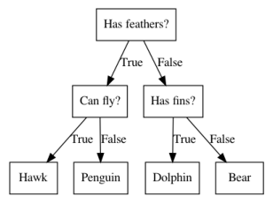

```python
# import image module
#from IPython.display import Image

# get the image
#Image(url="animals.png", width=600, height=600)

mglearn.plots.plot_animal_tree()
```

In this decision tree each node represents a question or a terminal node (also called a leaf) that contains an answer. The edges connect connect the answers to the question with the next. In ML language we built a model to distimquis between four classes using three features. We want to be able to learn these models from data:

### Building Decision Trees

We will use a data set consisting of 2 classes called the `two_moons` dataset:

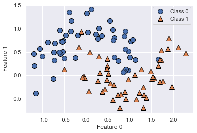

```python
from sklearn.datasets import make_moons
from mglearn.plot_helpers import discrete_scatter
plt.figure()
ax = plt.gca()
discrete_scatter(X[:, 0], X[:, 1], y, ax=ax)
ax.set_xlabel("Feature 0")
ax.set_ylabel("Feature 1")
plt.legend(["Class 0", "Class 1"], loc='best')
#print(two_moons)
#cm = ['b','r']
#plt.scatter(X[:, 0], X[:, 1], c=y, cmap=cm, edgecolors="k")
markers = ["o","^"]
#for i, c in enumerate(np.unique(y)):
#    plt.scatter(X[:,0][y==c],X[:,1][y==c],c=cm[i], marker=markers[i], edgecolors='k')
```

Learning a desision tree means learning the sequence of if/else questions that get us to the answer most quickly. In machine learning these questions are called tests. With our 2-D data set the features are continous and not binary as in the animal example. Therfore thes test that is used used is in the form of "Is feature i larger than value a?". To build a tree the algorithm searches over all possible test to fins the most informative about the target. We can see how this works for the first test on the two moons dataset:

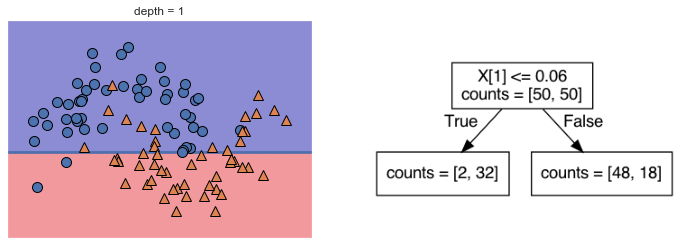

```python
from mglearn import plot_interactive_tree
from mglearn.plot_interactive_tree import plot_tree
from mglearn.plot_interactive_tree import tree_image
from sklearn.tree import DecisionTreeClassifier
#plot_interactive_tree.plot_tree_progressive()
max_depth=1
i=0
axes=[]
fig, ax = plt.subplots(1, 2, figsize=(12, 4),subplot_kw={'xticks': (), 'yticks': ()})
axes.append(ax)
axes = np.array(axes)

tree = plot_tree(X, y, max_depth=max_depth, ax=axes[i, 0])
axes[i, 1].imshow(tree_image(tree))
#axes[i, 1].set_axis_off()
```

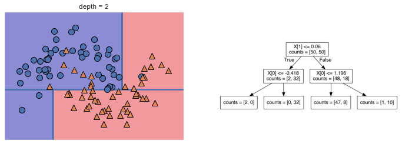

```python
max_depth=2
i=0
axes=[]
fig, ax = plt.subplots(1, 2, figsize=(12, 4),subplot_kw={'xticks': (), 'yticks': ()})
axes.append(ax)
axes = np.array(axes)

tree = plot_tree(X, y, max_depth=max_depth, ax=axes[i, 0])
axes[i, 1].imshow(tree_image(tree))
#axes[i, 1].set_axis_off()
```

This process creates a binary tree of decisions and each node contains a test. Another way of thinking about it is that each test partitions the feature space along one of the axes. The algorithm can be seen as building a hierarchial partition. Each test concerns a single feature and the resulting partitons have axis parallel boundaries. This processs can be repeated until each partition (also called leafs) onle contains a single value. These leaves are called pure leaves. To use the algorithm on a new data point we follow the tree until we reach the leaf where the new data point would be. The output would be the majority of points in that leaf.

This method can also be used for regression. To make predictions we traverse the tree to the leaft that would contain the point. The output of the data point would be the average of the terget data coantianed in that leaf.

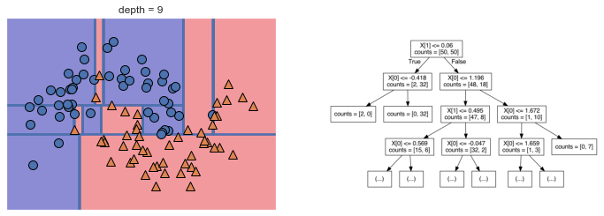

[output not shown]

```python
max_depth=9
i=0
axes=[]
fig, ax = plt.subplots(1, 2, figsize=(12, 4),subplot_kw={'xticks': (), 'yticks': ()})
axes.append(ax)
axes = np.array(axes)

tree = plot_tree(X, y, max_depth=max_depth, ax=axes[i, 0])
axes[i, 1].imshow(tree_image(tree))
#axes[i, 1].set_axis_off()
```

### Controlling complexity of decision trees

If you run the algorithm until all leaves are pure then you get a modle that is very complex and highly overfitt to the training data. The presence of pure leaves means that the model is 100% accurate on the training data. This can be seen in the figure above where on the left there are regions defined as being class 1 among all the class 0 points. Also on the right there is a single stip defined as class 0 among the class 1 region. This is not how we would imagine the decision boundary to look, the boundaries are focused on single outlier points that are far away from other points.

There are two common stratagies to prevent overfitting: stopping the tree early ( aaslo called *pre-pruning*) or building the tree and then collapsing nodes that contain little information (also called *post-pruning* or just *pruning*). Possible criteria for pre-pruning include limiting the max-depth of the tree, limiting the maximum number of leaves, or requiring a ninimum number of points in a node to keep splitting it.In scikit-leran only pre-pruning is implemented. We can look at the effect of pre-pruning using the breast cancer dataset:

```python
from sklearn.tree import DecisionTreeClassifier
cancer = load_breast_cancer()
X_train, X_test, y_train, y_test = train_test_split(cancer.data, cancer.target, stratify=cancer.target, random_state=42)
tree = DecisionTreeClassifier(random_state=0)
tree.fit(X_train, y_train)
print("Accuracy on training set: {:.3f}".format(tree.score(X_train, y_train)))
print("Accuracy on test set: {:.3f}".format(tree.score(X_test, y_test)))
```

```
Accuracy on training set: 1.000
Accuracy on test set: 0.937
```

As expected woth no pruning the accuracy on the training set is 100% becasue the leaves are pure. The accuracy on the test set is slightly worse when compared to the linear models which was around 95%. We can pre-prune by limiting the depth of the tree. This is the same as limiting the number of questions that can be asked. Lets see whet happens when we only have 4 questions or nodes:

```python
tree = DecisionTreeClassifier(max_depth=4, random_state=0)
tree.fit(X_train, y_train)
print("Accuracy on training set: {:.3f}".format(tree.score(X_train, y_train)))
print("Accuracy on test set: {:.3f}".format(tree.score(X_test, y_test)))
```

```
Accuracy on training set: 0.988
Accuracy on test set: 0.951
```

```python
from sklearn.tree import export_graphviz
export_graphviz(tree, out_file="tree.dot", class_names=["malignant", "benign"],
feature_names=cancer.feature_names, impurity=False, filled=True)
```

We can read the file and vizulize it using the graphviz module:

```python
import graphviz
with open("tree.dot") as f:
    dot_graph = f.read()
display(graphviz.Source(dot_graph))
```

[figure not shown]

### Feature inportance in Trees

Instead of lookng at the whole tree which have many nodes we can use some properties of the tree to derive and summerize the workings of the treee. The most commonly ussed tree summary i feature importance, which rates how important each feature is for the decision a tree makes. Each feature is assigned a value from 0 to 1 where 0 means not used at all and 1 means perfectly predicts the target. The feature importance always sums to 1. We can look at the feature importance for the breast cancer data:

```python
print("Feature importances:")
print(tree.feature_importances_)
```

```
Feature importances:
[0.     0.     0.     0.     0.     0.     0.     0.     0.     0.
 0.0102 0.0484 0.     0.     0.0024 0.     0.     0.     0.     0.
 0.7268 0.0458 0.     0.     0.0142 0.     0.0182 0.1221 0.0119 0.    ]
```

We can visualize the feature importance similar to how we visulized the weights in linear models:

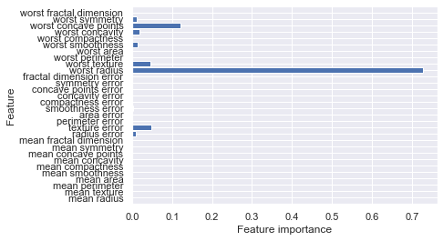

```python
def plot_feature_importances_cancer(model):
    n_features = cancer.data.shape[1]
    plt.barh(np.arange(n_features), model.feature_importances_, align='center')
    plt.yticks(np.arange(n_features), cancer.feature_names)
    plt.xlabel("Feature importance")
    plt.ylabel("Feature")
    plt.ylim(-1, n_features)

plot_feature_importances_cancer(tree)
```

Here we can see that the first feature used in the split is by far the most important feture. this also confirsts that using the first split already seperates the two classes firly well. If a feature has a low value in the feature importance it does not mean that it is uninformative but that it was not picked by the tree. This is likely because another feature encodes the same information. In contrast to the weights in linear models the feature impotrtance does not encode which class a feature is indicitive of. we know that worst radius is important, but not whether a high radius is indicitive of being begnin or malignant. In fact the relationship between features and class may not be as simple as seen in the following example:

```
Feature importances: [0. 1.]
```

[figure not shown]

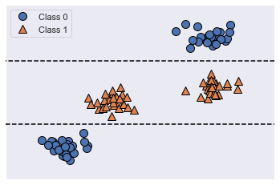

```python
tree = mglearn.plots.plot_tree_not_monotone()
display(tree)
```

The bottom plot shows a dataset with 2 features and 2 classes. All the information for the tree is based on feature 1 and not feature 0. The relationship between feature 1 and the output class is not monotonous, meaning we can not say a high value of mean s calss 0 and a low value of feature 1 means class 1 (or vice versa)

### Regression Models

We have focused on decision trees for classification but have noted that they could be used for regression. Trees for regression are implemented in DecisionTreeRegressor in scikit-learn. The important difference when using trees for regression is that they can not extrapolate, or make decisions outisode the range of the training data. To look at this we will consider historical prices of RAM data:

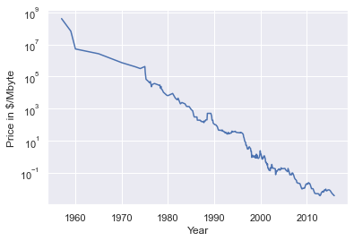

```python
import os
ram_prices = pd.read_csv(os.path.join(mglearn.datasets.DATA_PATH,"ram_price.csv"))
plt.semilogy(ram_prices.date, ram_prices.price)
plt.xlabel("Year")
plt.ylabel("Price in $/Mbyte");
```

Notice the logarithmic scale of the y-axis. When using a log scle for the y-axis the relationship seems quite linear so it should be relatively easy to predict.

To look at the forecasting of regression tree models we will forecast the ram price after 2000 using the historical data up till then. We will compare two simple models DecisionTreeRegressors and LinearRegression. We will scale the prices uinf a logarithmic transform so that the relationship is linear. This does not make a difference for the decison treee but does for the linear regression. After training the modles we undo the logarithm transform and vizzulize predictions on the whole dataset:

```
(202, 1)
```

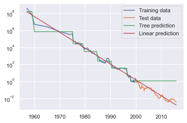

```python
from sklearn.tree import DecisionTreeRegressor
# use historical data to forecast prices after the year 2000
data_train = ram_prices[ram_prices.date < 2000]
data_test = ram_prices[ram_prices.date >= 2000]
# predict prices based on date
X_train = data_train.date.to_numpy()
X_train=np.reshape(X_train,(len(X_train),1))
print(X_train.shape)
# we use a log-transform to get a simpler relationship of data to target
y_train = np.log(data_train.price)
tree = DecisionTreeRegressor(max_depth=3).fit(X_train, y_train)
linear_reg = LinearRegression().fit(X_train, y_train)
# predict on all data
X_all = ram_prices.date.to_numpy()
X_all=np.reshape(X_all,(len(X_all),1))
pred_tree = tree.predict(X_all)
pred_lr = linear_reg.predict(X_all)
# undo log-transform
price_tree = np.exp(pred_tree)
price_lr = np.exp(pred_lr)

plt.semilogy(data_train.date, data_train.price, label="Training data")
plt.semilogy(data_test.date, data_test.price, label="Test data")
plt.semilogy(ram_prices.date, price_tree, label="Tree prediction")
plt.semilogy(ram_prices.date, price_lr, label="Linear prediction")
plt.legend()
```

### Strengths, Weaknesses, and Parameters

The paramter that controls the model complexity in trees is pre-pruning of the tree. This is done by picking either max_depth, max_leaf_nodes, or min_samples_leaf. Decision trees have two main adavatages over others discussed so far. The results are easy to visulizes and explain and they scale invariantly to the size of the problem. Decision trees work weel wehn the features have many different scales or there is a mis of binary and continous features.

The main doenfall of decision trees is that even with pre-pruning they tend to over fit and provide poor generalization. In practice what works well is creating an ensemble of decision trees.